# Exercise_3_stern_nicolas

Nicolas Stern

23 mars 2019

# Setup, Libraries

```r
library("e1071")
library(class)
```

# Daten laden

Das setup setzt voraus, das das Skript im Arbeitsverzeichnis abgelegt ist, und dass die *.csv Datein mit den Daten im selben Verzeichnis auch vorhanden ist.

```r
mnist_matrix = read.csv( 'MNIST.csv' )
```

# Fragen / Antworten über die Daten

1. Wieviele Bilder sind in der Matrix mnist_matrix encodiert

```r
dim(mnist_matrix)
```

```
## [1] 42000   785
```

Antwort: Die Matrix mit der Daten ist 42000 Zeilen Lang, jede Zeile enthält ein Bild.

2. Da es sich um einen Supervised Machine Learning task handelt muss ein Label (Target Variable) bereitgestellt sein - welche Spalte der Matrix enthält das Label?

Antwort: Die 1. Spalte der Matrix enthält das Label. Der Wertebereich der 1. Spalte wird wie folgt ersichtlich:

```r
sort(unique(mnist_matrix[,1]))
```

```
##  [1] 0 1 2 3 4 5 6 7 8 9
```

3. Wieviele Pixel haben die Bilder?

Antwort: jede Zeile hat 785 Spalten. 1. Spalte ist der Label, die restliche 784 Spalten enthalten die Pixel-Werte. Jedes Bild hat also 784 Pixels.

4. Wie hoch/breit sind die Bilder?

Antwort: Jedes Bild kann als 28 * 28 Quadrat ausgedruckt werden: (28 X 28 = 784)

# Print die ersten 10 Bilder mit dem Label

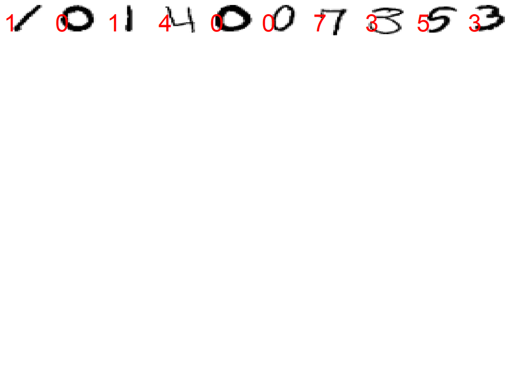

```r
par( mfrow = c(10, 10), mai = c(0,0,0,0))

for(i in 1:10){
  y = as.matrix(mnist_matrix[i, 2:785])
  dim(y) = c(28, 28)
  image( y[,nrow(y):1], axes = FALSE, col = gray(255:0 / 255))
  text( 0.2, 0, mnist_matrix[i,1], cex = 3, col = 2, pos = c(3,4))
}
```

# Daten Vorbereiten für Klassifizierung

Die Daten werden in einer Training Datenmenge und einer Test Datenmenge aufgetrennt. Die Training Datenmenge enthält 10% der Totalen Datenmenge.

```r
# Erstellen eines Samples für die Auftrennung Train- / Test -Daten
set.seed(123)
index = sample(2, nrow(mnist_matrix), replace=TRUE, prob=c(0.1, 0.9))
train_data_with_label = mnist_matrix[index==1,]
test_data_with_label = mnist_matrix[index==2,]

# Spalte mit Labels weglassen
train_data = train_data_with_label[-1]
test_data = test_data_with_label[-1]

# Vector der Labels erstellen
train_labels = factor(train_data_with_label[,1])
test_labels = factor(test_data_with_label[,1])
```

# Versuch einer Auswertung mit KNN

```r
pred_knn = knn(train = train_data,
               test = test_data,
               cl= train_labels,
               k = 10,
               prob=TRUE)

table(pred_knn, test_labels)
```

```
##         test_labels
## pred_knn    0    1    2    3    4    5    6    7    8    9
##        0 3643    0   72   13    4   22   38    4   24   19
##        1    2 4186  165   66  101   57   26  140  161   46
##        2    6    4 3281   31    1    2    8    8   18    7
##        3    0    1   38 3578    1  124    0    1  163   46
##        4    1    2    4    2 3257   13    7   14   23   54
##        5   25    0    9   59    2 3040   22    2  126    6
##        6   43    3   22   18   27   68 3614    1   26    3
##        7    2    6  110   59   17   12    0 3692   21  144
##        8    2    2   33   52    1    7    4    0 2996    7
##        9    6    3    9   39  257   63    0   68   86 3450
```

```r
# Auswertung
validate_knn = pred_knn == test_labels
good_knn = length(validate_knn[validate_knn==TRUE])
bad_knn = length(validate_knn[validate_knn==FALSE])
prop_good_knn <- good_knn / (good_knn + bad_knn)
```

Schlussfolgerung: mit KNN und einer Training - Datensatz von 10% der Gesamten Test-Datenmenge ist das Verhältnis der korrekten Voraussage 92.02 %.

# Versuch einer Auswertung mit Naive-Bayes

```r
model = naiveBayes(train_data, train_labels)
pred_nb = predict(model, test_data)
table(pred_nb, test_labels)
```

```
##        test_labels
## pred_nb    0    1    2    3    4    5    6    7    8    9
##       0 3436    1  313  409   34  567   51   93   72   38
##       1   18 4155  454  653  154  515  233  425 1278  321
##       2    8    0  642   20    3    8    7    1    8    1
##       3    7    1  572 1832   10  131    5   22   75    8
##       4    6    1   90   45  814   90   19   62   59   58
##       5    8    1  113   33   16  346   18    6   30    4
##       6   75   19  970  191  180  203 3196   22   97    8
##       7    0    0    7   37    6    4    1  899    2   13
##       8   24    8  385  149   46  676   28   24  987   16
##       9  148   21  197  548 2405  868  161 2376 1036 3315
```

```r
validate_nb = pred_nb == test_labels
good_nb = length(validate_nb[validate_nb == TRUE])
bad_nb  = length(validate_nb[validate_nb == FALSE])
prop_good_nb <- good_nb / (good_nb + bad_nb)
```

Schlussfolgerung: mit Naive-Bayes und einer Training - Datensatz von 10% der Gesamten Test-Datenmenge ist das Verhältnis der korrekten Voraussage 51.98 %.

# Erkenntnisse

Mit einer relativen kleinen Training Satz (10% der gesamten Datenmenge) erreicht man mit KNN eine korrekte Prognose in 92.02 % der Fälle. Mit der selben Proportion, erreicht man mit Naive-Bayes nur 51.98 % korrekte Prognose.

Wie sieht es aus mit einer grösseren Training Set, z.B. mit 1/4 der Daten?

```r
# Erstellen eines Samples für die Auftrennung Train- / Test -Daten
index2 = sample(2, nrow(mnist_matrix), replace=TRUE, prob=c(0.25, 0.75))
train_data_with_label2 = mnist_matrix[index2==1,]
test_data_with_label2 = mnist_matrix[index2==2,]

# Spalte mit Labels weglassen
train_data2 = train_data_with_label2[-1]
test_data2 = test_data_with_label2[-1]

# Vector der Labels erstellen
train_labels2 = factor(train_data_with_label2[,1])
test_labels2 = factor(test_data_with_label2[,1])

# Versuch einer Auswertung mit KNN

pred_knn2 = knn(train = train_data2,
               test = test_data2,
               cl= train_labels2,
               k = 10,
               prob=TRUE)

table(pred_knn2, test_labels2)
```

```
##          test_labels2
## pred_knn2    0    1    2    3    4    5    6    7    8    9
##         0 3077    0   41    5    1    9   28    6   21   15
##         1    1 3461   97   24   60   22   10   74   74   21
##         2    2    8 2817   18    0    0    0    9    8    5
##         3    0    1   27 3050    0   56    0    0   92   37
##         4    1    2   15    3 2807   11    4    7   20   26
##         5    3    0    3   48    0 2692   17    2   86   10
##         6   22    2   15    2   17   44 3051    1   20    3
##         7    0    5   89   31   10    4    0 3105   12   59
##         8    1    1   17   22    1    4    1    1 2644    5
##         9    2    0    7   25  161   39    0   68   59 2878
```

```r
# Auswertung
validate_knn2 = pred_knn2 == test_labels2
good_knn2 = length(validate_knn2[validate_knn2==TRUE])
bad_knn2 = length(validate_knn2[validate_knn2==FALSE])
prop_good_knn2<- good_knn2 / (good_knn2 + bad_knn2)

# Versuch einer Auswertung mit Naive-Bayes

model2 = naiveBayes(train_data2, train_labels2)
pred_nb2 = predict(model2, test_data2)
table(pred_nb2, test_labels2)
```

```
##         test_labels2
## pred_nb2    0    1    2    3    4    5    6    7    8    9
##        0 2826    0  467  485   90  597   38   49   85   30
##        1    7 3396  170  347   75  178   89  115  710  145
##        2   13    2  657   16   11   13    3    1    7    3
##        3    2    1  171  901    6   36    2    9   20    1
##        4    0    0    7    6  347   18    9   24   16   19
##        5    9    3   40   23   19  297   10   10   16    0
##        6  169   28 1063  303  376  294 2926   73  159   39
##        7    0    1    8   21    9    4    1  839    2    8
##        8   26   32  480  720  180  996   19   72 1333   41
##        9   57   17   65  406 1944  448   14 2081  688 2773
```

```r
validate_nb2 = pred_nb2 == test_labels2
good_nb2 = length(validate_nb2[validate_nb2 == TRUE])
bad_nb2  = length(validate_nb2[validate_nb2 == FALSE])
prop_good_nb2 <- good_nb2 / (good_nb2 + bad_nb2)
```

# Schlussfolgerung

Mit KNN und einer Training - Datensatz von 25% der Gesamten Test-Datenmenge ist das Verhältnis der korrekten Voraussage 94.32 % , und mit Naive-Bayes von 51.96 %. Das ist praktisch identisch, wie wenn die Testdaten nur 10% des gesamten Datenbestandes darstellen, bringt also keine notable Verbesserung.

Fazit: mit nur 10% des Datenbestandes hat man eine Training-Datensatz das eine Erfolgsquote über 90% ermöglicht.